# Data cleaning and exploration

Jody Daniel

2022-03-02

# 1 Background

We have two datasets: 1) basal area each year from 2006 to 2011 and 2) plant and environmental traits for each tree. Below, I aim to examine the data - assess data types, check for missingness, normality, outliers. Depending on the degree of missingness, I will impute the data as we would like to keep as many observations as possible.

# 2 Data Exploration

## Relative Growth Rate

Data summary

| Name | rgr_raw |
| --- | --- |
| Number of rows | 395 |
| Number of columns | 7 |
| _______________________ |  |
| Column type frequency: |  |
| character | 1 |
| numeric | 6 |
| ________________________ |  |
| Group variables | None |

**Variable type: character**

| skim_variable | n_missing | complete_rate | min | max | empty | n_unique | whitespace |
| --- | --- | --- | --- | --- | --- | --- | --- |
| SampleID | 0 | 1 | 6 | 10 | 0 | 395 | 0 |

**Variable type: numeric**

| skim_variable | n_missing | complete_rate | mean | sd | p0 | p25 | p50 | p75 | p100 | hist |
| --- | --- | --- | --- | --- | --- | --- | --- | --- | --- | --- |
| BA.0.2006 | 9 | 0.98 | 6.84 | 6.30 | 0.00 | 2.52 | 5.15 | 10.00 | 50.23 | ▇▂▁▁▁ |
| BA.0.2007 | 10 | 0.97 | 7.78 | 6.66 | 0.00 | 3.00 | 5.93 | 11.34 | 51.51 | ▇▃▁▁▁ |
| BA.0.2008 | 10 | 0.97 | 8.87 | 7.05 | 0.03 | 3.73 | 7.19 | 12.68 | 52.25 | ▇▃▁▁▁ |
| BA.0.2009 | 10 | 0.97 | 10.12 | 7.55 | 0.08 | 4.22 | 8.73 | 14.52 | 52.79 | ▇▅▁▁▁ |
| BA.0.2010 | 10 | 0.97 | 11.37 | 8.16 | 0.14 | 5.17 | 9.90 | 15.70 | 57.19 | ▇▅▁▁▁ |
| BA.0.2011 | 9 | 0.98 | 12.49 | 8.80 | 0.17 | 5.68 | 11.02 | 16.69 | 58.07 | ▇▆▂▁▁ |

## Traits & Environmnetal Conditions

Data summary

| Name | msh_raw |
| --- | --- |
| Number of rows | 395 |
| Number of columns | 70 |
| _______________________ |  |
| Column type frequency: |  |
| character | 3 |
| numeric | 67 |
| ________________________ |  |
| Group variables | None |

**Variable type: character**

| skim_variable | n_missing | complete_rate | min | max | empty | n_unique | whitespace |
| --- | --- | --- | --- | --- | --- | --- | --- |
| SampleID | 0 | 1 | 6 | 10 | 0 | 395 | 0 |
| Species | 0 | 1 | 3 | 4 | 0 | 25 | 0 |
| Site | 0 | 1 | 3 | 19 | 0 | 23 | 0 |

**Variable type: numeric**

| skim_variable | n_missing | complete_rate | mean | sd | p0 | p25 | p50 | p75 | p100 | hist |
| --- | --- | --- | --- | --- | --- | --- | --- | --- | --- | --- |
| Height.DBH.Ratio | 0 | 1.00 | 149.74 | 41.48 | 66.27 | 120.00 | 144.62 | 173.81 | 292.00 | ▃▇▅▂▁ |
| Estem | 0 | 1.00 | 4056.54 | 3332.23 | 360.90 | 1670.37 | 3158.50 | 5437.74 | 21146.10 | ▇▃▁▁▁ |
| Etwig | 0 | 1.00 | 343.40 | 192.69 | 22.95 | 201.00 | 312.16 | 431.57 | 1124.22 | ▆▇▂▁▁ |
| Branching.Distance | 0 | 1.00 | 23.93 | 21.27 | 5.13 | 11.09 | 16.14 | 27.30 | 100.00 | ▇▂▁▁▁ |
| Twig.Diameter | 0 | 1.00 | 5.58 | 1.81 | 3.02 | 4.46 | 5.15 | 6.25 | 15.60 | ▇▃▁▁▁ |
| Twig.Wood.Density | 0 | 1.00 | 0.50 | 0.08 | 0.27 | 0.46 | 0.51 | 0.55 | 0.68 | ▁▃▇▇▂ |
| Stem.Wood.Density | 0 | 1.00 | 0.62 | 0.13 | 0.26 | 0.52 | 0.60 | 0.73 | 0.90 | ▁▅▇▇▃ |
| Leaf.Mass.Fraction | 0 | 1.00 | 1.29 | 0.64 | 0.24 | 0.81 | 1.16 | 1.65 | 3.53 | ▆▇▃▂▁ |
| Leaf.Area | 0 | 1.00 | 59.36 | 78.31 | 3.74 | 18.28 | 29.78 | 61.92 | 474.46 | ▇▁▁▁▁ |
| LMA | 0 | 1.00 | 52.56 | 24.28 | 17.46 | 32.96 | 45.39 | 67.76 | 134.22 | ▇▆▃▂▁ |
| LCC | 0 | 1.00 | 47.50 | 2.37 | 41.73 | 46.06 | 47.62 | 49.13 | 52.51 | ▂▃▇▆▂ |
| LNC | 0 | 1.00 | 2.69 | 0.51 | 1.42 | 2.34 | 2.68 | 3.00 | 4.18 | ▁▆▇▃▁ |
| LPC | 0 | 1.00 | 15.39 | 4.84 | 5.54 | 12.07 | 14.47 | 17.84 | 41.30 | ▅▇▂▁▁ |
| d15N | 0 | 1.00 | -2.23 | 2.84 | -9.04 | -4.11 | -2.20 | -0.75 | 16.19 | ▃▇▁▁▁ |
| t.b2 | 7 | 0.98 | 0.03 | 0.01 | 0.00 | 0.02 | 0.02 | 0.03 | 0.06 | ▁▇▆▂▁ |
| Ks | 8 | 0.98 | 117.03 | 144.75 | 10.98 | 39.29 | 57.40 | 122.21 | 985.83 | ▇▁▁▁▁ |
| Ktwig | 8 | 0.98 | 1156.31 | 901.76 | 90.73 | 622.43 | 899.15 | 1331.78 | 7135.09 | ▇▂▁▁▁ |
| Huber.Value | 4 | 0.99 | 0.14 | 0.63 | 0.00 | 0.01 | 0.01 | 0.02 | 6.00 | ▇▁▁▁▁ |
| X.Lum | 8 | 0.98 | 0.13 | 0.04 | 0.04 | 0.10 | 0.13 | 0.16 | 0.28 | ▂▇▇▂▁ |
| VD | 8 | 0.98 | 10521.05 | 9850.27 | 1988.89 | 5195.75 | 6765.92 | 10350.06 | 53249.44 | ▇▁▁▁▁ |
| X.Sapwood | 4 | 0.99 | 0.76 | 0.28 | 0.01 | 0.72 | 0.90 | 0.96 | 1.00 | ▁▁▁▂▇ |
| d13C | 0 | 1.00 | -30.23 | 1.46 | -33.83 | -31.36 | -30.42 | -29.31 | -25.82 | ▂▇▇▃▁ |
| Biomass5 | 11 | 0.97 | 6.18 | 7.91 | 0.03 | 1.69 | 3.93 | 7.63 | 86.06 | ▇▁▁▁▁ |
| pcent.max.Bio5 | 11 | 0.97 | 0.31 | 0.29 | 0.00 | 0.09 | 0.21 | 0.45 | 1.00 | ▇▃▂▁▂ |
| Symmetric.Competition | 9 | 0.98 | 2.73 | 3.89 | 0.02 | 0.61 | 1.32 | 3.26 | 27.06 | ▇▁▁▁▁ |
| Asymmetric.Competition | 9 | 0.98 | 20.28 | 23.15 | 0.22 | 4.43 | 13.08 | 27.55 | 149.31 | ▇▂▁▁▁ |
| Soil.Humidity | 0 | 1.00 | 0.15 | 0.16 | 0.00 | 0.06 | 0.11 | 0.19 | 1.00 | ▇▂▁▁▁ |
| SoilpH | 130 | 0.67 | 5.13 | 0.73 | 3.61 | 4.57 | 5.09 | 5.66 | 7.19 | ▃▇▇▃▁ |
| Organic.C | 130 | 0.67 | 11.08 | 10.06 | 0.69 | 3.24 | 7.45 | 14.37 | 44.29 | ▇▃▁▂▁ |
| N | 130 | 0.67 | 0.46 | 0.48 | 0.01 | 0.10 | 0.27 | 0.58 | 2.11 | ▇▂▁▁▁ |
| P | 130 | 0.67 | 32.24 | 39.69 | 2.16 | 12.02 | 18.10 | 33.93 | 322.54 | ▇▁▁▁▁ |
| K | 130 | 0.67 | 138.25 | 95.18 | 24.25 | 67.22 | 112.80 | 189.70 | 533.14 | ▇▅▁▁▁ |
| Ca | 130 | 0.67 | 2075.00 | 2312.22 | 116.92 | 505.75 | 1351.81 | 2564.65 | 14134.25 | ▇▁▁▁▁ |
| Mg | 130 | 0.67 | 107.01 | 93.32 | 9.41 | 40.22 | 78.69 | 149.28 | 615.70 | ▇▃▁▁▁ |
| Soil.Depth | 82 | 0.79 | 33.19 | 14.81 | 3.00 | 21.00 | 30.00 | 46.00 | 55.00 | ▂▆▇▃▇ |
| Slope | 0 | 1.00 | 8.65 | 10.19 | 0.00 | 0.00 | 5.30 | 15.00 | 39.60 | ▇▃▂▁▁ |
| North.Aspect | 0 | 1.00 | -0.17 | 0.49 | -1.00 | -0.51 | 0.00 | 0.00 | 0.99 | ▃▁▇▁▁ |
| East.Aspect | 0 | 1.00 | 0.06 | 0.51 | -1.00 | 0.00 | 0.00 | 0.24 | 1.00 | ▂▁▇▁▂ |
| Elevation | 0 | 1.00 | 142.49 | 76.47 | 40.00 | 81.50 | 146.00 | 200.00 | 350.00 | ▆▇▅▁▁ |
| Summer.Max | 0 | 1.00 | 27.17 | 1.61 | 24.17 | 26.17 | 26.67 | 27.75 | 32.17 | ▂▇▂▃▁ |
| Fall.Min | 0 | 1.00 | -10.22 | 1.27 | -14.67 | -10.83 | -10.50 | -9.50 | -8.00 | ▁▁▇▆▅ |
| Mean.Temp | 0 | 1.00 | 13.72 | 0.58 | 12.31 | 13.32 | 13.83 | 14.10 | 14.67 | ▁▃▅▇▅ |
| X.Canopy.Opening | 0 | 1.00 | 9.19 | 7.94 | 1.06 | 4.76 | 6.40 | 10.50 | 57.01 | ▇▁▁▁▁ |
| Tree.Age | 6 | 0.98 | 20.82 | 10.39 | 5.00 | 14.00 | 17.00 | 26.00 | 66.00 | ▇▅▂▁▁ |
| Tree.Height | 0 | 1.00 | 423.42 | 131.45 | 170.00 | 328.50 | 404.60 | 509.00 | 932.09 | ▅▇▅▁▁ |
| julian.date.2011 | 0 | 1.00 | 194.35 | 12.19 | 171.00 | 186.00 | 193.00 | 204.00 | 218.00 | ▃▃▇▃▃ |
| Branch.Height | 0 | 1.00 | 3.04 | 1.03 | 1.20 | 2.30 | 2.90 | 3.65 | 6.80 | ▅▇▅▂▁ |
| SRL | 242 | 0.39 | 105.80 | 60.11 | 14.18 | 64.26 | 92.01 | 143.75 | 288.14 | ▇▇▅▂▁ |
| Root.Wood.Density | 196 | 0.50 | 0.57 | 0.10 | 0.30 | 0.51 | 0.57 | 0.64 | 0.85 | ▁▅▇▆▁ |
| Twig.branching.angle | 100 | 0.75 | 53.77 | 16.99 | 0.00 | 46.88 | 54.95 | 64.58 | 102.83 | ▁▂▇▅▁ |
| Hmax | 0 | 1.00 | 20.26 | 9.22 | 5.00 | 12.00 | 25.00 | 25.00 | 35.00 | ▆▅▂▇▅ |
| Shade.Tolerance | 37 | 0.91 | 2.78 | 1.14 | 1.21 | 1.56 | 2.59 | 3.56 | 4.76 | ▇▆▅▅▃ |
| Drought.Tolerance | 37 | 0.91 | 2.48 | 0.70 | 1.50 | 1.77 | 2.38 | 2.92 | 4.00 | ▇▃▆▂▂ |
| WaterLogging.Tolerance | 37 | 0.91 | 1.79 | 0.77 | 1.00 | 1.07 | 1.50 | 2.50 | 3.37 | ▇▂▂▃▂ |
| DBH.DGH | 0 | 1.00 | 0.68 | 0.11 | 0.29 | 0.62 | 0.69 | 0.74 | 0.97 | ▁▂▇▇▁ |
| Leaf.Area.Ratio | 0 | 1.00 | 266.39 | 134.27 | 32.15 | 165.33 | 243.93 | 349.29 | 756.66 | ▅▇▃▁▁ |
| Branch.Dry.Mass | 0 | 1.00 | 5.58 | 4.07 | 1.06 | 2.98 | 4.46 | 6.62 | 30.69 | ▇▂▁▁▁ |
| Leaf.Thickness | 0 | 1.00 | 0.13 | 0.04 | 0.06 | 0.11 | 0.13 | 0.15 | 0.24 | ▂▇▅▂▁ |
| Leaf.Density | 0 | 1.00 | 0.38 | 0.10 | 0.14 | 0.31 | 0.37 | 0.44 | 0.69 | ▂▇▇▃▁ |
| C.N | 0 | 1.00 | 18.28 | 3.73 | 10.25 | 15.72 | 17.72 | 20.37 | 35.22 | ▃▇▃▁▁ |
| C.P | 0 | 1.00 | 3.35 | 1.00 | 1.16 | 2.65 | 3.25 | 3.98 | 8.32 | ▃▇▃▁▁ |
| N.P | 0 | 1.00 | 0.19 | 0.05 | 0.06 | 0.15 | 0.18 | 0.22 | 0.42 | ▂▇▆▁▁ |
| Kl | 8 | 0.98 | 811.54 | 817.60 | 154.67 | 349.40 | 466.03 | 730.06 | 4545.35 | ▇▁▁▁▁ |
| Kleaf | 8 | 0.98 | 1.45 | 2.06 | 0.01 | 0.49 | 0.93 | 1.64 | 22.47 | ▇▁▁▁▁ |
| Biomass1 | 11 | 0.97 | 1.23 | 1.98 | 0.00 | 0.24 | 0.55 | 1.29 | 18.15 | ▇▁▁▁▁ |
| pcent.max.Bio1 | 11 | 0.97 | 0.25 | 0.27 | 0.00 | 0.05 | 0.13 | 0.32 | 1.00 | ▇▂▁▁▁ |
| Total.Transmitted.Light | 0 | 1.00 | 5.54 | 5.11 | 0.63 | 2.64 | 3.82 | 6.14 | 36.18 | ▇▁▁▁▁ |

# 3 Imputation

Might be best to just drop some the columns trait values with a large % of missing data.

For the trait data, I will simply remove those with a majority of missing cases before running the imputation - I am thinking of using a cut of less than 50%.

```r
# removing cases with a bunch of zeroes
MSH.50 <- msh_raw[,names(which(sapply(colnames(msh_raw), function (x) {sum(is.na(msh_raw[,x]))/nrow(msh_raw)<0.5})))]
MSH.5 <- msh_raw[,names(which(sapply(colnames(msh_raw), function (x) {sum(is.na(msh_raw[,x]))/nrow(msh_raw)<0.05})))]
# I only want columns that are numeric
numeric_columns_msh <- which(apply(MSH.50,2, function (x) !is.na(mean(as.numeric(x), na.rm = TRUE))))
numeric_columns_rgr <- which(apply(rgr_raw,2, function (x) !is.na(mean(as.numeric(x), na.rm = TRUE))))
# I read somewhere that p>5 does not change the overall values significantly So, I will stick to that number of datasets.
MSH.IP.MICE <- mice(data.matrix(MSH.50[,numeric_columns_msh]),
               printFlag = FALSE, method = "pmm", m = 5, seed = 300)
```

Let’s combine the imputed data - just to check if a regression would give different results.

```r
library(abind)
MSH.IP.List <- list()
m_length <- MSH.IP.MICE$m
for (i in 1:m_length){
    MSH.IP.List[[i]] <- mice::complete(MSH.IP.MICE, action = i)}
MSH.IP.Final <- data.frame(apply(abind(MSH.IP.List, along=3), c(1,2), mean))
```

Now, I will run the imputation on these data. Since I have removed the columns with a large amount of missing cases, the imputation should work. If not, I will set a more stringent condition.

```
##
## Call:
## lm(formula = Tree.Height ~ Soil.Depth + Biomass1 + Huber.Value +
##     SoilpH)
##
## Residuals:
##     Min      1Q  Median      3Q     Max
## -257.24  -97.69  -18.73   88.62  521.91
##
## Coefficients:
##             Estimate Std. Error t value Pr(>|t|)
## (Intercept) 394.2091    54.5395   7.228  2.6e-12 ***
## Soil.Depth    0.6374     0.4620   1.380 0.168478
## Biomass1     12.1384     3.4642   3.504 0.000512 ***
## Huber.Value -18.8910    11.3104  -1.670 0.095675 .
## SoilpH       -0.9036     9.9056  -0.091 0.927362
## ---
## Signif. codes:  0 '***' 0.001 '**' 0.01 '*' 0.05 '.' 0.1 ' ' 1
##
## Residual standard error: 129.4 on 390 degrees of freedom
## Multiple R-squared:  0.04095,    Adjusted R-squared:  0.03112
## F-statistic: 4.163 on 4 and 390 DF,  p-value: 0.002584
```

```
##
## Call:
## lm(formula = Tree.Height ~ Soil.Depth + Biomass1 + Huber.Value +
##     SoilpH, data = msh_raw)
##
## Residuals:
##     Min      1Q  Median      3Q     Max
## -275.02 -100.11  -25.28   87.24  527.31
##
## Coefficients:
##             Estimate Std. Error t value Pr(>|t|)
## (Intercept) 376.5703    60.2157   6.254 1.67e-09 ***
## Soil.Depth    0.4151     0.5481   0.757   0.4495
## Biomass1     20.7473     4.6604   4.452 1.27e-05 ***
## Huber.Value 313.5464   135.3190   2.317   0.0213 *
## SoilpH        1.9247    11.0954   0.173   0.8624
## ---
## Signif. codes:  0 '***' 0.001 '**' 0.01 '*' 0.05 '.' 0.1 ' ' 1
##
## Residual standard error: 130.9 on 256 degrees of freedom
##   (134 observations deleted due to missingness)
## Multiple R-squared:  0.09589,    Adjusted R-squared:  0.08176
## F-statistic: 6.788 on 4 and 256 DF,  p-value: 3.307e-05
```

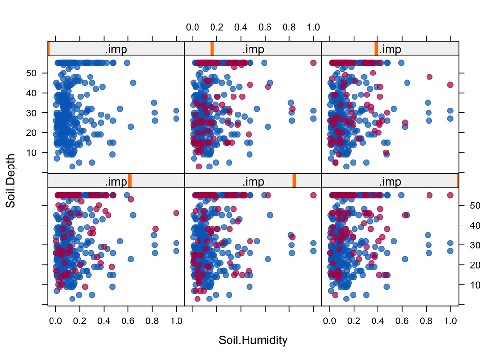

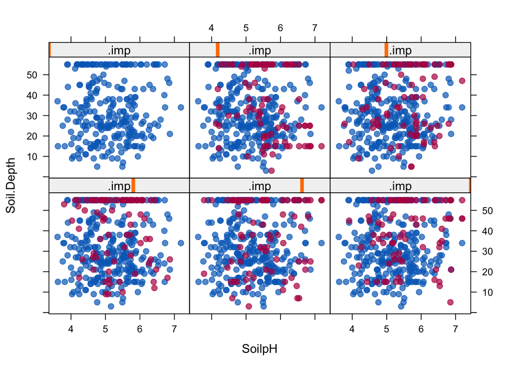

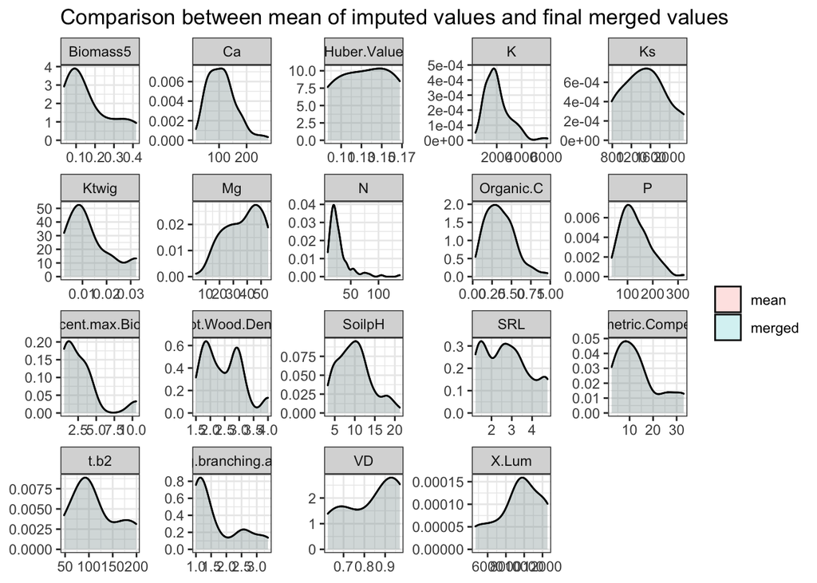

There is strong overlap between the mean and merged values. As such, I can be confident that the merged data set is representative of individual imputations.

# 4 Estimate Growth Rate

```r
# makes more sense to name the rows by their sample ID as a unique identifier
MSH.IP.Final$SampleID <- rgr_raw[,1]

MSH.RGR_IMP <- merge(rgr_raw,MSH.IP.Final, by = "SampleID")
MSH.RGR <- merge(rgr_raw,MSH.50, by = "SampleID")
# now for growth rate parameters
BAI_GR <- with(data = MSH.RGR_IMP, exp = ((BA.0.2011 - BA.0.2006)/5))
BIO_Gain <- with(data = MSH.RGR_IMP,
    exp = ((BA.0.2011*Stem.Wood.Density*Tree.Height*3)-(BA.0.2006*Stem.Wood.Density*(Tree.Height/Tree.Age*(Tree.Age-6))*3)))
BIO_2006 <- with(data = MSH.RGR_IMP,
                 exp = (BA.0.2006*Stem.Wood.Density*(Tree.Height/Tree.Age*(Tree.Age-6))*3))
BIO_GR <- BIO_Gain/((BIO_2006+1)*5)
# wanna place species and site at the start of the data frame
SiteInfo <- c("SampleID", "Site", "Species")
RGR_MSH_Final <-
  MSH.RGR_IMP %>% select(-SampleID) %>% bind_cols(MSH.50 %>% select(SiteInfo)) %>%
  mutate(BAI_GR = BAI_GR,
         BIO_GR = BIO_GR)%>%
  select(any_of(c(OthersKeep,"BAI_GR","BIO_GR", PlantTraitsKeep,EnvironmentalVariablesKeep)))%>% relocate(c(BAI_GR, BIO_GR), .before = Species)

# now for growth rate parameters
BAI_GR_NA <- with(data = MSH.RGR, exp = ((BA.0.2011 - BA.0.2006)/5))
BIO_Gain_NA <- with(data = MSH.RGR, exp = ((BA.0.2011*Stem.Wood.Density*Tree.Height*3) - (BA.0.2006*Stem.Wood.Density*(Tree.Height/Tree.Age*(Tree.Age-6))*3)))
BIO_2006_NA <- with(data = MSH.RGR, exp = (BA.0.2006*Stem.Wood.Density*(Tree.Height/Tree.Age*(Tree.Age-6))*3))
BIO_GR_NA <- BIO_Gain_NA/((BIO_2006_NA+1)*5)

RGR_MSH_NA_Final <-
  MSH.50 %>%
  mutate(BAI_GR = BAI_GR_NA,
         BIO_GR = BIO_GR_NA)%>%
  select(any_of(c(OthersKeep,"BAI_GR","BIO_GR", PlantTraitsKeep,EnvironmentalVariablesKeep))) %>% relocate(c(BAI_GR, BIO_GR), .before = Species)

write_csv(RGR_MSH_Final,here("data/RGR_MSH.csv"))
write_csv(RGR_MSH_NA_Final,here("data/RGR_MSH_NA.csv"))
```